# An analysis of F1

06/07/2021

## Part 1

- In the history of Formula 1 has constancy been more important than winning?
- To answer this first question we will count how many times a driver has won a F1 title without getting the most number of wins.
- But first how many times do you think this has happened in 71 seasons of F1?

## First plot

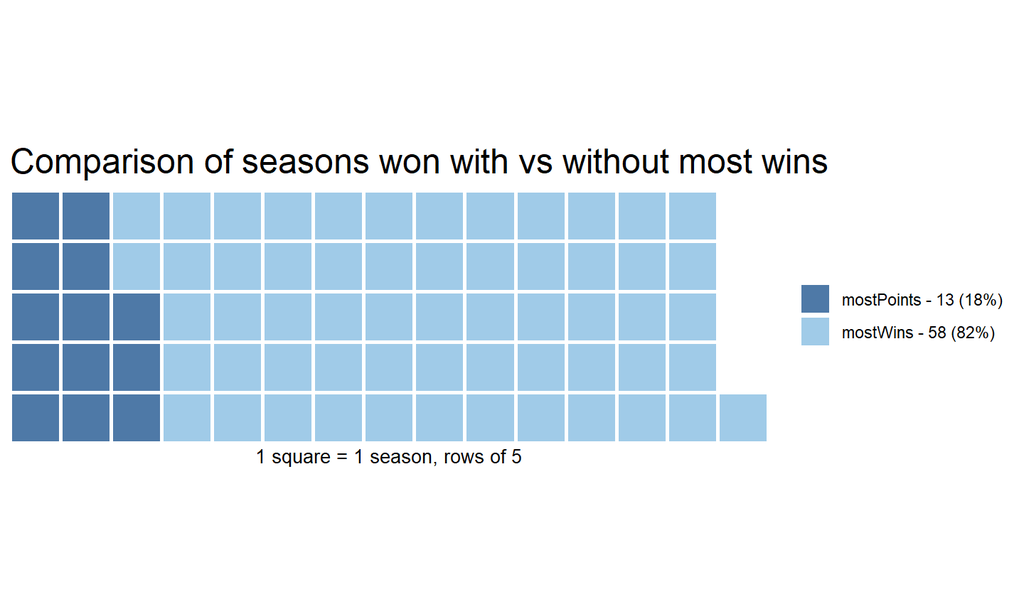

## Second plot

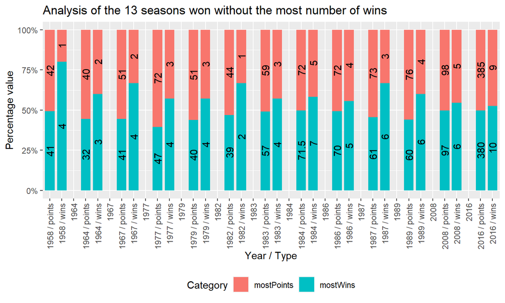

## Fun fact 1

- In 1984 the season became a memorable duel between McLaren drivers Alain Prost and Niki Lauda.
- Prost won seven races to Lauda’s five, including the last two races of the season, but Lauda eventually prevailed by half a point; the smallest margin in Formula One history.
- It was Lauda’s third title, and his first since 1977.
- McLaren comfortably won the Manufacturers’ Championship, their first since 1974.

## Conclusion 1

- Winning in F1 is generally important because 82% of the time getting the most number of wins has led to the won of the title.
- In fact on average winning a title without having the most wins happens only 1 time every 5½ seasons.

## Part 2

- If winning is so important in F1, how important is starting in front of the grid to be on the top step of the podium?
- To answer this second question we will count the occurrences of wins by initial grid position.
- But first what is the percentage of wins you expect starting from pole position?

## First plot

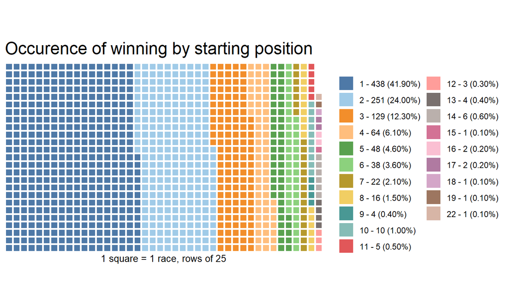

## Second plot

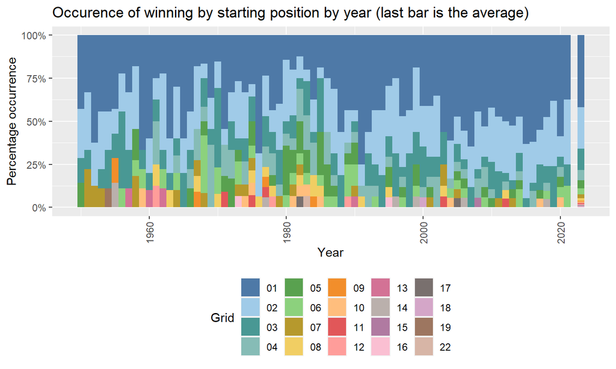

## Fun fact 2

- The record in the history of F1 of the most backward start for a grand prix winner was performed by John Watson starting 22nd on the United States Grand Prix West of 1983 with McLaren.
- That was his fifth, and last, success in the world championship.
- His teammate, Niki Lauda, who finished second, started instead from the 23rd place.

## Conclusion 2

- In the history of F1 starting from the pole has usually been very important as on average it has led to more than 40% of victories.
- Second place, instead, led to almost ¼ of victories and third to only around ⅛ of wins.
- Below the third place the percentages lower below 10%

## Part 3

- Now that we know how the starting position is related to the probability of getting a win, how different are percentages in Monaco, which is a classic street circuit that usually do not offer many overtakes?
- To answer this final question we will use the same process as before but focusing on the difference between the average of all circuits and Monaco GP.
- But first what is the percentage of wins you expect this time starting from pole position remembering that on average is 41.9%?

## First plot

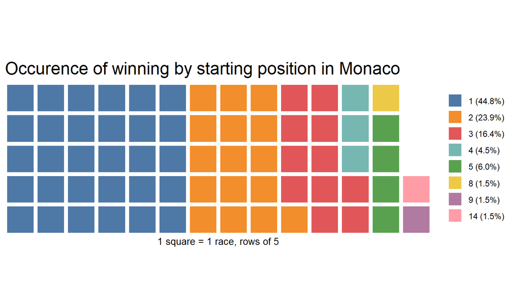

## Second plot

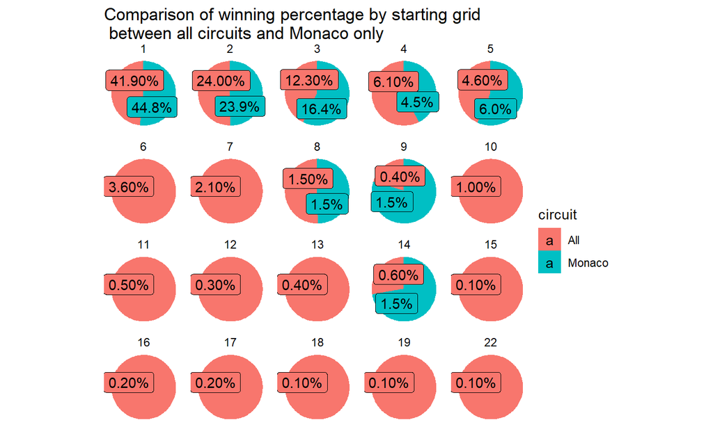

## Fun fact 3

- The driver who has won starting 14th on the Monaco Grand Prix was Olivier Panis in 1996 with Ligier.
- The race took place in extremely wet asphalt conditions and that was his only victory in Formula 1.
- Only four cars reached the finish line, of which only three at full rpm.
- According to the regulations, the race was stopped at the limit of two hours after the start, when only 75 laps of the 78 planned had been completed.

## Conclusion 3

- The difference between all circuits and only Monaco is not very significant.
- The percentage difference starting on pole position is only 3% and the other position are very similar too.
- In conclusion we can say that in F1 great comebacks that led to a win are not very common neither on proper circuits nor on street circuit, with only a little difference between those.